# Ford GoBike / Lyft Bay Wheels Data Analysis

## by Chris Palmer

- A summary explanation of features of the Ford GoBike / Lyft Bay Wheels data
- Detailed data preparation, exploratory and explanatory analysis have been conducted in other notebooks

[figure not shown]

# Main Findings

# The Notebooks

There are four notebooks involved, in order of their development:

1. [Data\_Visualization\_Project_DataSetup.ipynb](https://github.com/ChrisPalmerNZ/Udacity_Data_Visualization/blob/master/Data_Visualization_Project_DataSetup.ipynb) - used to extract the data from the CSV files and save it into a SQLite database
2. [Data\_Visualization\_Project\_DataExploration.ipynb](https://github.com/ChrisPalmerNZ/Udacity_Data_Visualization/blob/master/Data_Visualization_Project_DataExploration.ipynb) - used to explore and describe the data, and to add features that aid analysis. The enhanced data is then saved into a new table in the database, ready for explanatory data analysis.
3. [Data\_Visualization\_Project\_DataExplanation.ipynb](https://github.com/ChrisPalmerNZ/Udacity_Data_Visualization/blob/master/Data_Visualization_Project_DataExplanation.ipynb) - used to conduct the explanatory data analysis an construct visuals, including various permutations of some of the charts.
4. [Data\_Visualization\_Project\_DataExplanation\_Slides.ipynb](https://github.com/ChrisPalmerNZ/Udacity_Data_Visualization/blob/master/Data_Visualization_Project_DataExplanation_Slides.ipynb) - a version of the exlpanatory notebook reorganized and dedicated to presenting the insights as a slide show.

# Dataset overview

- The data consists of aboput 5.8 million records, consisting of time, geographical and user-type information of individual trips, from June 2017 until March 2020.
- There is no subscriber identification and little customer-specific information, except for gender and birth year information collected from June 2017 to April 2019.
- Data was obtained from the [archives](https://s3.amazonaws.com/baywheels-data/index.html) linked to from the [System Data](https://www.fordgobike.com/system-data) page of the Lyft Bikes web site
- The data consists of a CSV file for the 2017 year, and zip files containing a CSV for each remaining month thereafter
- There are around 5.8 million rows in the data
- Data has been loaded, combined, augmented and saved into a SQL Lite database as the table tripdata_fixed

### Data structure according to the System Data page

Each trip is anonymized and includes:

- Trip Duration (seconds)
- Start Time and Date
- End Time and Date
- Start Station ID
- Start Station Name
- Start Station Latitude
- Start Station Longitude
- End Station ID
- End Station Name
- End Station Latitude
- End Station Longitude
- Bike ID
- User Type (Subscriber or Customer)
  - Subscriber = Member
  - Customer = Casual

### Core data structure

- Extra fields were found in some CSV files, these were combined into one database
- `duration_sec` - length of trip in seconds
- `start_time` - trip start datetime
- `end_time` - trip end datetime
- `start_station_id` - start station id
- `start_station_name` - start station name
- `start_station_latitude` - start station latitude
- `start_station_longitude` - start station longitude
- `end_station_id` - end station id
- `end_station_name` - end station name
- `end_station_latitude` - end station latitude
- `end_station_longitude` - end station longitude
- `bike_id` - bike id
- `user_type` - user type
- `member_birth_year` - year of member's birth
- `member_gender` - member's gender
- `bike_share_for_all_trip` - was 'bike share' used for all the trip
- `rental_access_method` - rental access method
- `member_birth_year`, `member_gender`, `bike_share_for_all_trip` and `rental_access_method`
  - not used in all data, but in common because the data is stored in one table

### Added columns continued...

- `end_month` - the number of the `end_time` month (1 to 12)
- `end_month_name` - the name of the `end_time` month (January etc.)
- `end_day` - the number of the `end_time` day (1 to 31)
- `end_day_name` - the name of the `end_time` day (Monday etc.)
- `end_hour` - the number of the `end_time` hour (1 to 24)
- `has_start_id` - boolean to indicate that a start station id exists (1=True, 0=False)
- `has_start_name` - boolean to indicate a start station name exists (1=True, 0=False)
- `has_end_id` - boolean to indicate that a start station id exists (1=True, 0=False)
- `has_end_name` - boolean to indicate a start station name exists (1=True, 0=False)
- `member_age` - member age, derived from `member_birth_year` but corrected where needed based on assumptions of data entry errors
- `age_group` - age groups to allow for easier aggregation of age
  - 18-25, 25-30, 30-35, 35-40, 40-45, 45-50, 50-55, 55-60, 60-70, 70+
- `age_grp_order` - integer to signify correct order of age groups
- `yearmonth` `start_time` year and month, but aligned with `datasource` where 1st of following month records are included
- `reccount` a value of 1 to allow for SQL sum of aggregated records

# 1. Trip monthly counts analysis

- The following slides analyze data in terms of counts per month and week,
- with particular attention to the last part of the data, where numbers decrease dramatically

## 1.a Trips per month seasonal pattern

- The chart summarizes trips per month from the combined 2018 and 2019 years
- The US fall to winter months of November and December show a decrease, which begins increasing again in January and more so by March
- Peak usage months are July and October

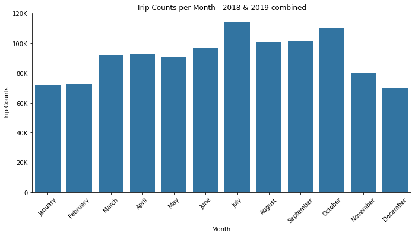

```python
base_color = sns.color_palette()[0]
sns.catplot(data = df_counts.loc[df_counts.year_name.isin(['2018','2019'])],
            x = 'start_month_name',
            y = 'trip_count', kind="bar",
            color = base_color,
            ci=None,
            height=5,
            aspect=2);

plt.xlabel('Month')
plt.ylabel('Trip Counts')
plt.title('Trip Counts per Month - 2018 & 2019 combined')
plt.xticks(rotation=45)
ax = plt.gca()
ax.yaxis.set_major_formatter(FuncFormatter(reformat_large_tick_values))
plt.show();
```

## 1.b Trips per month

- The data stretches from June 2017 to March 2020
- The monthly figures show a gradual increase over the years
- Seasonal fluctuations occur
  - the US fall to winter months of November and December show a decrease,
  - which begins increasing again in January and more so by March
- However, the 2019 year also has a dip around April to June, and a spike in July

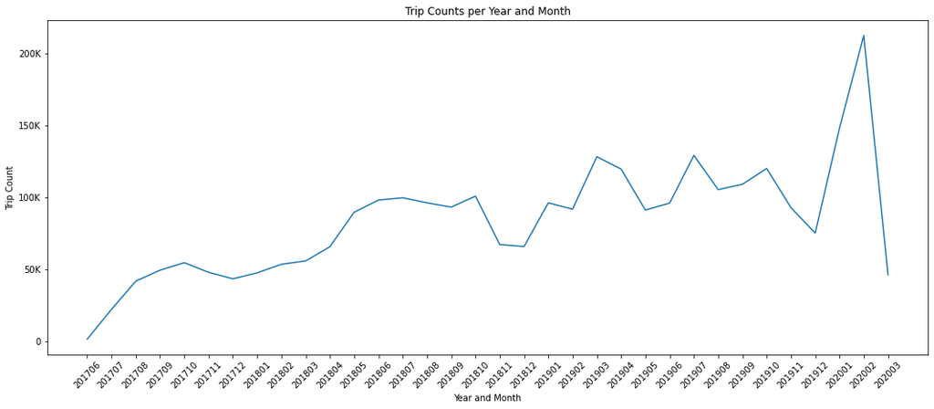

```python
f = plt.figure(figsize=(18, 7))
ax = sns.lineplot(x="yearmonth", y="trip_count",
                  data=df_counts, ci=None)
plt.xlabel('Year and Month')
plt.ylabel('Trip Count')
plt.title('Trip Counts per Year and Month')
plt.xticks(rotation=45)
ax.yaxis.set_major_formatter(FuncFormatter(reformat_large_tick_values))
plt.show();
```

### Trips per month analysis

> Six Bay Area counties announced "shelter in place" orders for all residents on Monday — the strictest measure of its kind yet in the continental United States — directing everyone to stay inside their homes and away from others as much as possible for the next three weeks in a desperate move to curb the rapid spread of coronavirus across the region.  
> The directive was set to begin at 12:01 a.m. Tuesday and involves San Francisco, Santa Clara, San Mateo, Marin, Contra Costa and Alameda counties — a combined population of more than 6.7 million. It is to stay in place until at least April 7. The three other Bay Area counties — Sonoma, Solano and Napa — did not issue similar mandates.  
> Just outside the Bay Area, Santa Cruz County late Monday also announced a "shelter in place" order for its 275,000 residents.

### March 16th 2020 - Californian counties to "shelter in place"...

[figure not shown]

## 1.c Trips per month user types

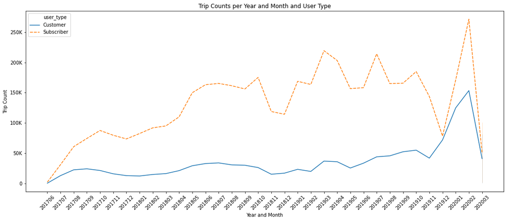

```python
f = plt.figure(figsize=(18, 7))
ax = sns.lineplot(x="yearmonth", y="trip_count",
                  hue="user_type",
                  style="user_type",
                  data=df_counts)

plt.xlabel('Year and Month')
plt.ylabel('Trip Count')
plt.title('Trip Counts per Year and Month and User Type')
plt.xticks(rotation=45)
ax.yaxis.set_major_formatter(FuncFormatter(reformat_large_tick_values))
plt.show();
```

### 1.c (i) Trips detail per day over January to March 2020

- The next chart (scroll down) shows the variation of daily usage over the last 3 months of data, emphasizing the February spike
- Both subscribers and customers use bikes far more during the week,
  - the usage for both is much higher in February 2020,
  - and the subscribers are also relatively much higher than customers in February
  - also in February, subscribers riding in the weekend exceeded even the customers during the week
- In March the numbers have declined dramatically, except for a spike in subscribers on Sunday

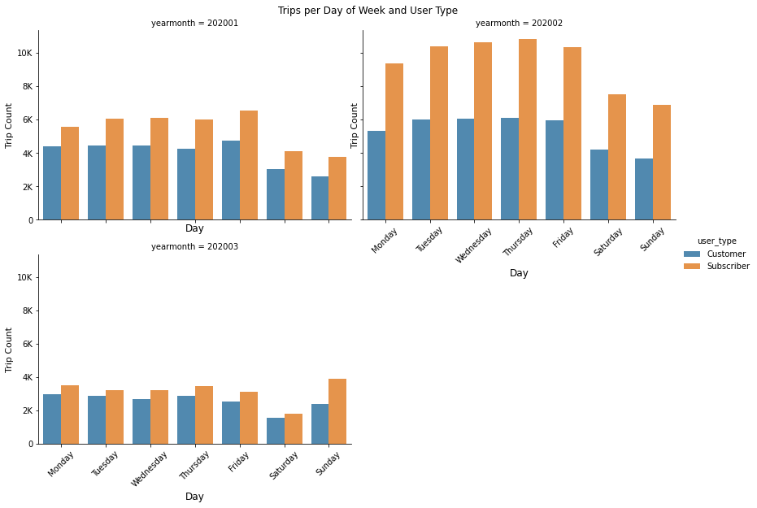

```python
g = sns.catplot(x="start_day_name",
                y="trip_count",
                hue="user_type",
                col="yearmonth",
                alpha=0.85,
                col_wrap=2,
                data=df_daily_counts,
                ci=None,
                kind="bar",
                #legend_out=False,
                #legend=False,
                height=4, aspect=1.5)

#plt.legend(loc='upper right')

g.fig.suptitle('Trips per Day of Week and User Type', y=1.01)
for ax in g.axes.flatten():
    ax.set_xlabel('Day', fontsize=12)
    ax.set_ylabel('Trip Count', fontsize=11)
    ax.yaxis.set_major_formatter(FuncFormatter(reformat_large_tick_values))

g.set_xticklabels(rotation=45)
plt.show();
```

### 1.c (ii) The daily patterns are very much higher for subscribers, for a period

- at the beginning of January subscribers are less that casual customers
- from around 15th January subscriber numbers grow to as much as twice as many as casual customers
- then drop off to be about the same, very much lower figure, after 1st March
- there is one slightly higher jump in subscriber trips on 1st March, but otherwise there is nothing distinctive about any single day
- the saw-tooth effect is because of the weekly to weekend usage patterns

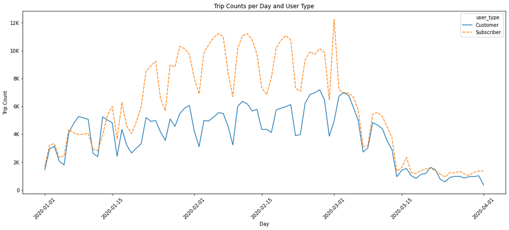

```python
f = plt.figure(figsize=(18, 7))
ax = sns.lineplot(x="start_date",
                  y="trip_count",
                  hue="user_type",
                  style="user_type",
                  data=df_daily_counts)
plt.xticks(rotation=45)
plt.xlabel('Day')
plt.ylabel('Trip Count')
plt.title('Trip Counts per Day and User Type')
plt.xticks(rotation=45)
ax.yaxis.set_major_formatter(FuncFormatter(reformat_large_tick_values))
plt.show();
```

### 1.c (iii) The final days of February going into March 2020

- the saw-tooth pattern reflects weekly usage
- the uncharacteristic jump in subscriber trips on 1st March, which was a Sunday, could be a last round of rides on an expiring subscription
- the large jump of subscribers on this particular Sunday explains the increase in subscribers noted above in the weekly pattern for March
- after that numbers plummet for both type of user
- what is the reason for this fluctuation?

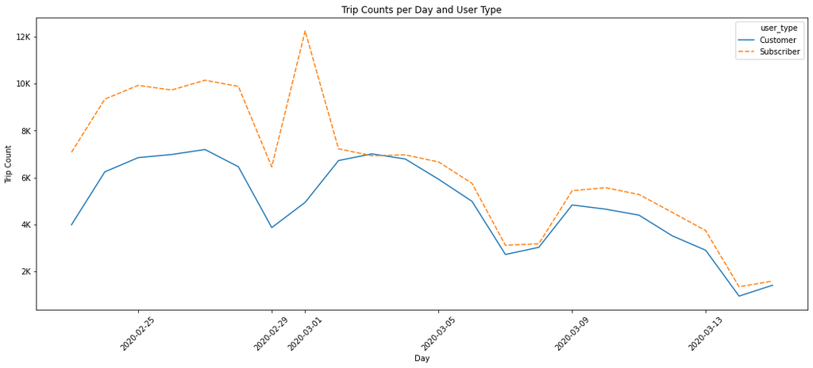

```python
f = plt.figure(figsize=(18, 7))
ax = sns.lineplot(x="start_date",
                  y="trip_count",
                  hue="user_type",
                  style="user_type",
                  data=df_daily_counts.loc[(df_daily_counts.start_date>=pd.Timestamp('2020-02-23'))
                                         & (df_daily_counts.start_date<=pd.Timestamp('2020-03-15'))])
plt.xticks(rotation=45)
plt.xlabel('Day')
plt.ylabel('Trip Count')
plt.title('Trip Counts per Day and User Type')
plt.xticks(rotation=45)
ax.yaxis.set_major_formatter(FuncFormatter(reformat_large_tick_values))
plt.show();
```

# Trip monthly counts conclusion

## Is Lyft or something worse "killing the golden goose" in SF?

- The majority of users are subscribers
- Subscribers are more clearly seasonal and perhaps allow their membership to lapse in winter months, certainly their usage decreases
- Fluctuating interest in the program seems to be linked to availability of e-bikes
- The re-introduction of e-bikes in later December 2019 was followed by a large increase of users, especially subscribers
- It is possible that the uncharacteristically high patronage that followed was due to people trying e-bikes before an impending price rise
- and, it is reasonable to infer that increased membership prices for e-bikes has led to a decreased patronage in March 2020
- However, we can definitely blame an extraordinary event for a downturn in Subscriber activity - the [announcement](https://www.sfchronicle.com/local-politics/article/Bay-Area-must-shelter-in-place-Only-15135014.php#photo-19180983) on March 16th that residents must "shelter in place" in Northern California due to coronavirus!

[figure not shown]

# 2. Trip hourly counts analysis

- the following charts explore the hour when trips are taken, in relation to user type and day

## 2.a Distribution of trip counts per hour of day

- the plots show overall frequencies of trip starting times for all usage, per hour
- there are two peaks in usage pattern at commuting times
- this suggests that commuting is a major motivation for hiring the bikes
- people are still starting trips past 11 p.m. (23) but there are very few after that until a renewed uptake starting at 5 a.m.

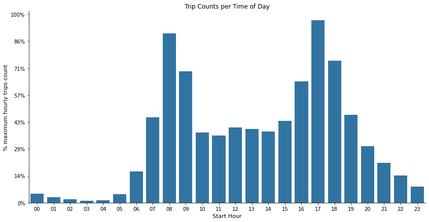

```python
base_color = sns.color_palette()[0]
sns.catplot(data = summary_hrs, x = 'start_hour_name', y = 'trip_count', kind="bar",
                color = base_color, height=6, aspect=2);
plt.xlabel('Start Hour', fontsize=11)
plt.ylabel('% maximum hourly trips count', fontsize=11)
plt.title('Trip Counts per Time of Day', fontsize=12)

#perc_fmt = plt.gca().axes.get_ylim()[1]  # df_duration_summary.trip_count.sum()
#print(perc_fmt)  # 711157.65
perc_fmt = 700000 # plt.gca().axes.get_ylim()[1]  # df_duration_summary.trip_count.sum()

plt.gca().yaxis.set_major_formatter(PercentFormatter(perc_fmt
                                                    , decimals=0
                                                    ))
plt.show();
```

## 2.b Distribution of "Bike Share for All Trip" counts per hour

- the plot shows frequencies for 'Bike Share for All Trip' usage only, per hour
- the numbers increase steadily from 5 a.m. to a peak at 5 p.m. then drop off
- the pattern suggests people who are increasingly getting out for a bike ride as the day goes on, and not with consideration to a morning commute
- the [Bike Share for All](https://www.lyft.com/bikes/bay-wheels/bike-share-for-all) web page says that "Bay Area residents who qualify for CalFresh, SFMTA Lifeline Pass, or PG&E CARE utility discount are eligible"

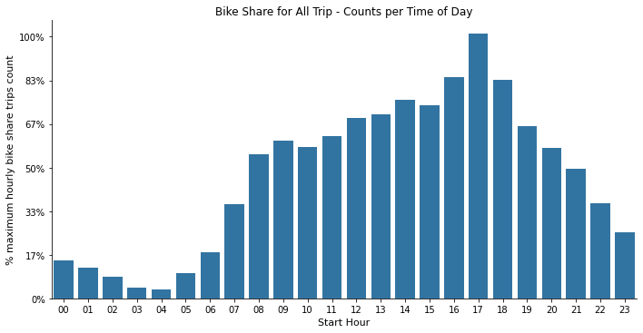

```python
base_color = sns.color_palette()[0]
sns.catplot(data = summary_bike_share_hrs, x = 'start_hour_name', y = 'trip_count', kind="bar",
                color = base_color, height=5, aspect=2);
plt.xlabel('Start Hour', fontsize=11)
plt.ylabel('% maximum hourly bike share trips count', fontsize=11)
plt.title('Bike Share for All Trip - Counts per Time of Day', fontsize=12)

# perc_fmt = plt.gca().axes.get_ylim()[1]  # df_duration_summary.trip_count.sum()
# print(perc_fmt)  # 31888.5
perc_fmt = 30000 # plt.gca().axes.get_ylim()[1]  # df_duration_summary.trip_count.sum()

plt.gca().yaxis.set_major_formatter(PercentFormatter(perc_fmt
                                                    , decimals=0
                                                    ))
plt.show();
```

## 2.c Distribution of trip counts per hour of day of week

- the plots shows relative counts for all usage, per hour of the day and day of the week
- the daily commuting patterns exists only on week days,
- on weekends there is a gradual increase from 8am, with maximums between midday and 5pm, then trailing off to the day's end

### Trips per Time and Day of Week, % day trips count

- the y-axis represents the percentage contribution of each hour to the total daily count

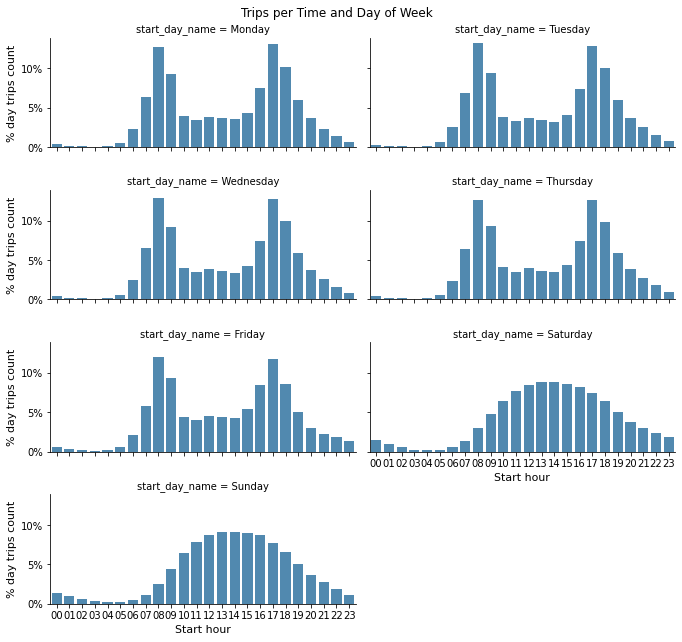

```python
base_color = sns.color_palette()[0]
g = sns.catplot(x="start_hour_name",
                y="day_frequency",
                col="start_day_name",
                alpha=0.85,
                col_wrap=2,
                data=summary_days,
                ci=None,
                kind="bar",
                color = base_color,
                height=2.2, aspect=2.2)

g.fig.suptitle('Trips per Time and Day of Week', y=1.01, fontsize=12)

for (i, ax) in enumerate(g.axes.flatten()):
    if i >= 5:
        ax.set_xlabel('Start hour', fontsize=11)
    if i % 2 == 0:
        plt.gca().yaxis.set_major_formatter(PercentFormatter(1, decimals=0))
        ax.set_ylabel('% day trips count', fontsize=11)

plt.show();
```

### Bike Share Trips per Time and Day of Week, % day trips count

- the y-axis represents the percentage contribution of each hour to the total daily count

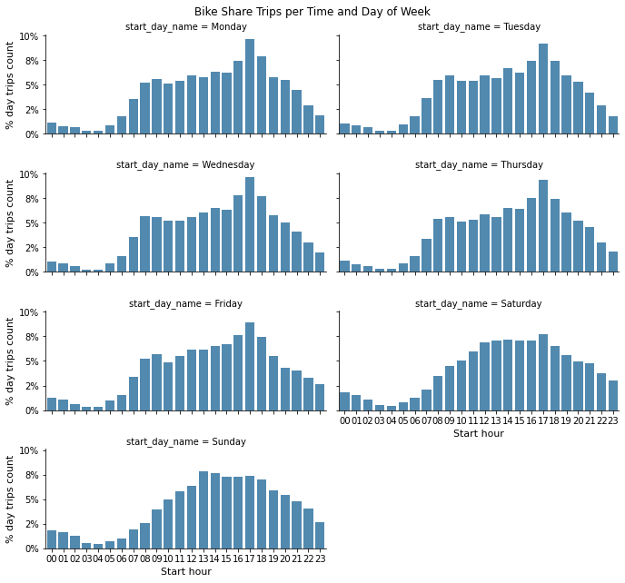

```python
base_color = sns.color_palette()[0]
g = sns.catplot(x="start_hour_name",
                y="day_frequency",
                col="start_day_name",
                alpha=0.85,
                col_wrap=2,
                data=summary_bike_share_days,
                ci=None,
                kind="bar",
                color = base_color,
                height=2.2, aspect=2.2)

g.fig.suptitle('Bike Share Trips per Time and Day of Week', y=1.01, fontsize=12)

for (i, ax) in enumerate(g.axes.flatten()):
    if i >= 5:
        ax.set_xlabel('Start hour', fontsize=11)
    if i % 2 == 0:
        plt.gca().yaxis.set_major_formatter(PercentFormatter(1, decimals=0))
        ax.set_ylabel('% day trips count', fontsize=11)

plt.show();
```

## 2.d Distributions of peak hourly usage

### per Subscribers and Customers per Day

- A heatmap shows that the maximum frequencies of usage times for both Subscribers and Customers is at 8am and 5pm during the week
- The spread of peak times on week days is wider for Subscribers
- But Customers are using the service considerably more frequently during the middle part of the weekend days

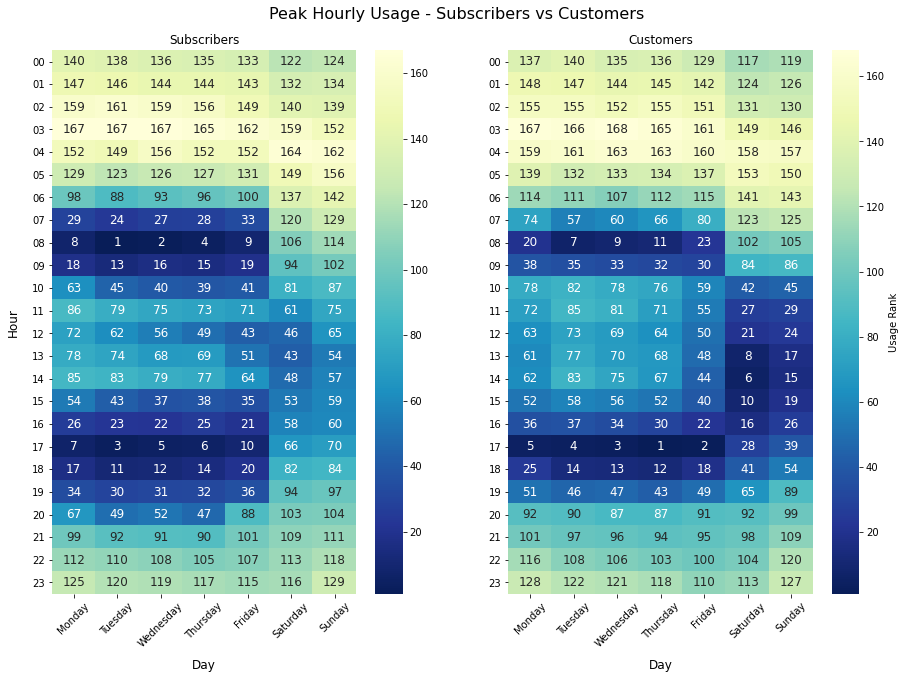

```python
plt.figure(figsize=(15,10))

plt.subplot(121)
plt.suptitle('Peak Hourly Usage - Subscribers vs Customers', y=0.94, fontsize=16)
sns.heatmap(subscriber_days_pivoted, fmt='d', annot=True, cmap='YlGnBu_r', annot_kws={"size": 12})
plt.title("Subscribers")
plt.xlabel('Day', labelpad=10, fontsize = 12)
plt.ylabel('Hour', labelpad=12, fontsize = 12)
plt.xticks(rotation = 45)
plt.yticks(rotation=360);

plt.subplot(122)
sns.heatmap(customer_days_pivoted, fmt='d', annot=True, cmap='YlGnBu_r',
            annot_kws={"size": 12}, cbar_kws={'label': 'Usage Rank'})
plt.title("Customers")
plt.xlabel('Day', labelpad=10, fontsize = 12)
plt.ylabel(' ')
plt.xticks(rotation = 45);
plt.yticks(rotation=360);
```

# Trip hourly counts conclusion

- There is a pattern around commuting during the week, with a peak around 8 to 9 a.m. and another around 5 p.m.
- There are differences between standard Subscribers and "Bike Share Trips" Subscribers, the latter tend not to have the commuting pattern
- Although Customers also exhibit some of the commuting pattern they also have more trips outside of it, particularly on weekends

# 3. Trip Duration analysis

- the following charts explore the spread of trip durations in minutes
- most trips are less than 30 minutes long

## 3.a Distribution of minutes up to 1 hour duration

- the distribution is heavily skewed
- restricting the view to a one hour window makes it easier to view the data
- restricting to an hour, the mean is 11.5 minutes, the 50% percentile is 9.4 minutes
- unrestricted, the mean 14.1 minutes, the 50% percentile is 9.5 minutes

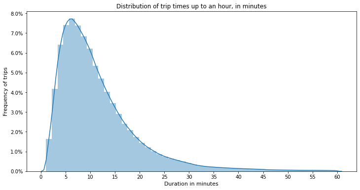

```python
f = plt.figure(figsize=(12, 6))
ax = sns.distplot(df_minutes.loc[df_minutes.duration_min <= 60, ["duration_min"]]);
stepsize = 5
start, end = (0, 65)
ax.xaxis.set_ticks(np.arange(start, end, stepsize))
ax.set_xlabel('Duration in minutes', fontsize=11)
ax.set_ylabel('Frequency of trips', fontsize=11)
plt.gca().yaxis.set_major_formatter(PercentFormatter(1))
plt.title('Distribution of trip times up to an hour, in minutes')
plt.show();
```

## 3.b Distribution of Bike Share rides up to 1 hour duration

- "Bike Share for All Trip" distribution is very similar to the overall distribution, the mean is one minute less

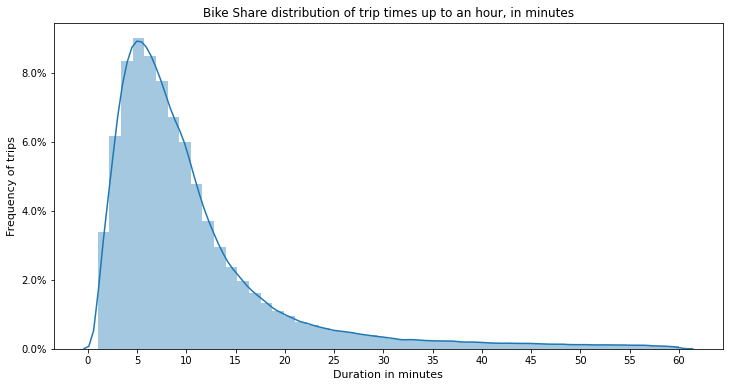

```python
f = plt.figure(figsize=(12, 6))
ax = sns.distplot(df_minutes.loc[
    (df_minutes.bike_share_for_all_trip=='Yes') &
    (df_minutes.duration_min <= 60),
    ["duration_min"]]);
stepsize = 5
start, end = (0, 65)
ax.xaxis.set_ticks(np.arange(start, end, stepsize))
ax.set_xlabel('Duration in minutes', fontsize=11)
ax.set_ylabel('Frequency of trips', fontsize=11)
plt.gca().yaxis.set_major_formatter(PercentFormatter(1))
plt.title('Bike Share distribution of trip times up to an hour, in minutes')
plt.show();
```

## 3.c Log distribution of minutes up to 2 hours duration

- A log scale helps to visualize the data in the smaller increments where most data is found

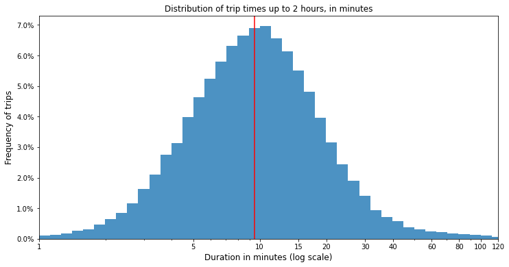

```python
f = plt.figure(figsize=(12, 6))
log_binsize = 0.05
bins = 10 ** np.arange(0, np.log10(df_120_min.duration_min.max()) + log_binsize, log_binsize)

plt.hist(data = df_120_min, x = 'duration_min',
         weights=np.ones(len(df_120_min)) / len(df_120_min),
         bins = bins, alpha=0.8)
plt.xscale('log')
plt.xticks([1, 5, 10, 15, 20, 30, 40, 60, 80, 100, 120], [1, 5, 10, 15, 20, 30, 40, 60, 80, 100, 120])
plt.xlim((1, 120))
plt.xlabel('Duration in minutes (log scale)', fontsize=12)
plt.ylabel('Frequency of trips', fontsize=12)
plt.axvline(x = df_120_min.duration_min.median(), color = 'red')
plt.gca().yaxis.set_major_formatter(PercentFormatter(1))
plt.title('Distribution of trip times up to 2 hours, in minutes')
plt.show();
```

## 3.d Distribution of minutes up to 2 hours duration, by working day or weekend

- Weekend trips are longer, the distribution is not so heavily skewed as the weekday distribution
- Weekday trips have a mean of 11.5 minutes and 50% percentile of 9.3
- Weekend trips have a mean of 15.1 minutes and 50% percentile of 10.75

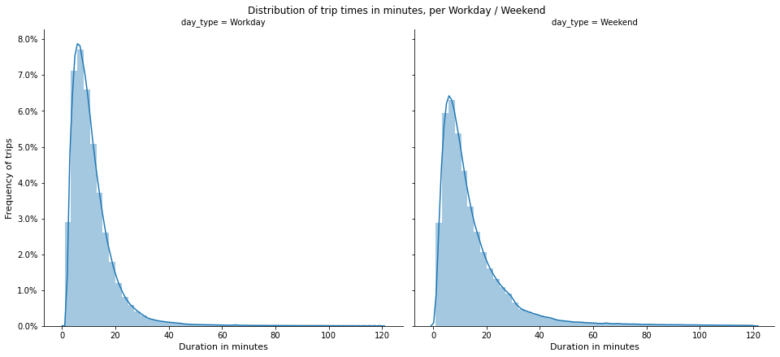

```python
g = sns.FacetGrid(df_120_min,
                  col="day_type", height=6, aspect=1.1)
g.map(sns.distplot, "duration_min")
g.fig.suptitle('Distribution of trip times in minutes, per Workday / Weekend', y=1.01)
for (i, ax) in enumerate(g.axes.flatten()):
    ax.set_xlabel('Duration in minutes', fontsize=11)
    if i == 0:
        ax.set_ylabel('Frequency of trips', fontsize=11)
plt.gca().yaxis.set_major_formatter(PercentFormatter(1))

plt.show();
```

## 3.e Comparisons of average trip duration over user types

- the following charts explore the average duration per user type per day

### Average Trip durations per week

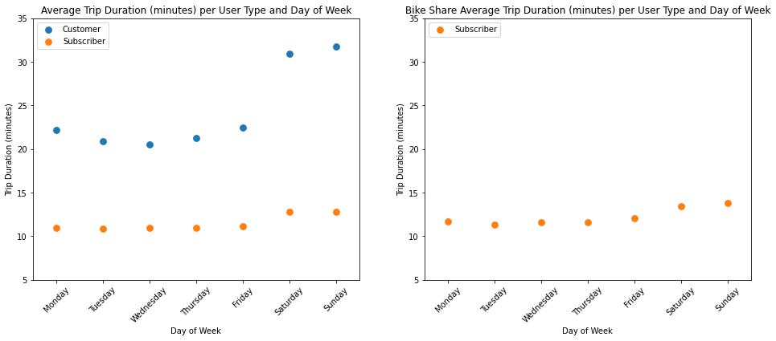

```python
plt.figure(figsize=[16, 6])

plt.subplot(1, 2, 1)
sns.pointplot(data = df_trip_summary,
              x = 'start_day_name', y = 'duration_min', hue = 'user_type',
            linestyles = "")
plt.ylim(5, 35)
plt.legend(loc='upper left')
plt.xticks(rotation = 45)
plt.xlabel('Day of Week')
plt.ylabel('Trip Duration (minutes)')
plt.title('Average Trip Duration (minutes) per User Type and Day of Week')

plt.subplot(1, 2, 2)
subscriber_color = sns.color_palette()[1:]
sns.pointplot(data = df_bike_share_trip_summary,
              x = 'start_day_name', y = 'duration_min', hue = 'user_type',
            linestyles = "", palette=subscriber_color)
plt.ylim(5, 35)
plt.legend(loc='upper left')
plt.xticks(rotation = 45)
plt.xlabel('Day of Week')
plt.ylabel('Trip Duration (minutes)')
plt.title('Bike Share Average Trip Duration (minutes) per User Type and Day of Week')

plt.show();
```

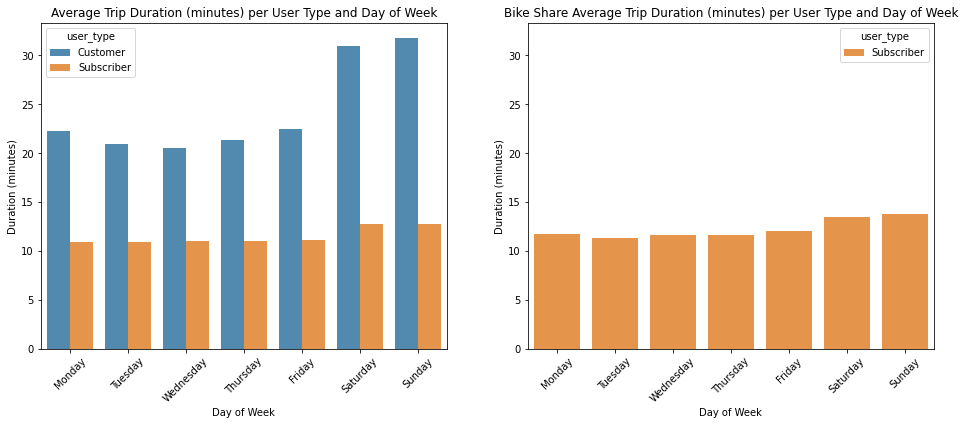

```python
plt.figure(figsize=[16, 6])

plt.subplot(1, 2, 1)
sns.barplot(data = df_trip_summary,
              x = 'start_day_name', y = 'duration_min', hue = 'user_type', alpha=0.85)
plt.xticks(rotation = 45)
plt.xlabel('Day of Week')
plt.ylabel('Duration (minutes)')
plt.title('Average Trip Duration (minutes) per User Type and Day of Week')
bottom, top = plt.ylim()

plt.subplot(1, 2, 2)
sns.barplot(data = df_bike_share_trip_summary,
              x = 'start_day_name', y = 'duration_min', hue = 'user_type', alpha=0.85,
              palette=sns.color_palette()[1:])
plt.ylim(top=top)
plt.xticks(rotation = 45)
plt.xlabel('Day of Week')
plt.ylabel('Duration (minutes)')
plt.title('Bike Share Average Trip Duration (minutes) per User Type and Day of Week')

plt.show();
```

### Average trip durations per month

- Measured over the two complete years of 2018 and 2019
- Customer trip durations are highly dependent on month, they drop markedly from August to December, then jump right up again in January
- Subscriber trip durations are very consistent, only slightly higher in June, July and September

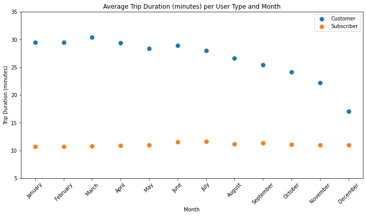

```python
plt.figure(figsize=[12, 6])

sns.pointplot(data = df_monthly_trip_summary,
              x = 'start_month_name', y = 'duration_min', hue = 'user_type',
            linestyles = "")
plt.ylim(5, 35)
plt.legend(loc='upper right')
plt.xticks(rotation = 45)
plt.xlabel('Month')
plt.ylabel('Trip Duration (minutes)')
plt.title('Average Trip Duration (minutes) per User Type and Month')
plt.show();
```

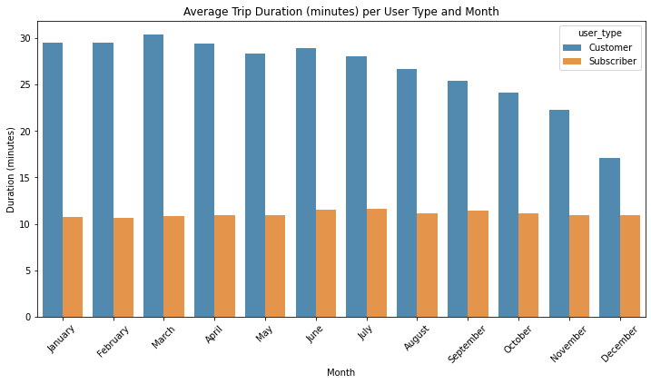

```python
plt.figure(figsize=[12, 6])

ax = sns.barplot(data = df_monthly_trip_summary,
              x = 'start_month_name', y = 'duration_min', hue = 'user_type', alpha=0.85)
plt.xticks(rotation = 45)
plt.xlabel('Month')
plt.ylabel('Duration (minutes)')
plt.title('Average Trip Duration (minutes) per User Type and Month')
plt.show();
```

### Average monthly trip durations, comparing years

- The large differences between Customers and Subscribers are reflected in yearly differences
- Subscriber levels are fairly consistent for the 2018 and 2019 years
- But Customer levels have decreased markedly over the two years

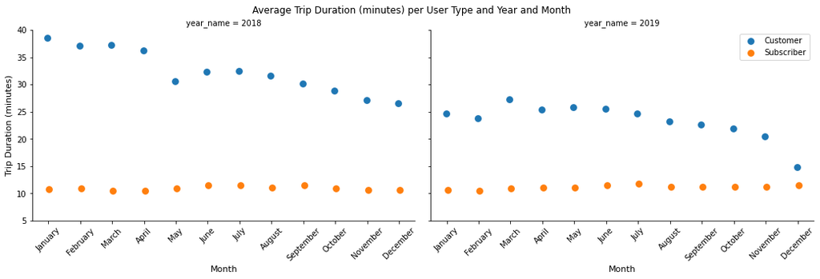

```python
g = sns.catplot(x="start_month_name", y="duration_min",
                hue="user_type", col="year_name",
                data=df_yearmonthly_trip_summary, kind="point",
                dodge=True,
                linestyles = "",
                legend=False,
                height=4.3, aspect=1.7)
plt.ylim(5, 40)
plt.legend(loc='upper right')

g.fig.suptitle('Average Trip Duration (minutes) per User Type and Year and Month', y=1.02, fontsize=12)
for (i, ax) in enumerate(g.axes.flatten()):
    ax.set_xticklabels(ax.get_xticklabels(), rotation = 45)
    ax.set_xlabel('Month', fontsize=11)
    if i == 0:
        ax.set_ylabel('Trip Duration (minutes)', fontsize=11)
plt.show();
```

### To understand current usage, using the 2019 year only

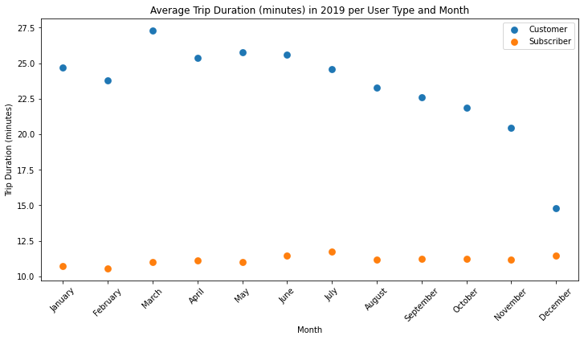

```python
plt.figure(figsize=[12, 6])

sns.pointplot(data = df_2019_monthly_summary,
              x = 'start_month_name', y = 'duration_min', hue = 'user_type',
            linestyles = "")
#plt.ylim(5, 35)
plt.legend(loc='upper right')
plt.xticks(rotation = 45)
plt.xlabel('Month')
plt.ylabel('Trip Duration (minutes)')
plt.title('Average Trip Duration (minutes) in 2019 per User Type and Month')
plt.show();
```

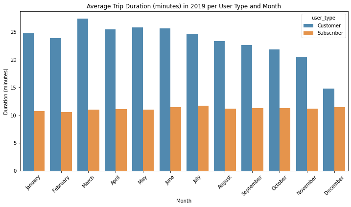

```python
plt.figure(figsize=[12, 6])

ax = sns.barplot(data = df_2019_monthly_summary,
              x = 'start_month_name', y = 'duration_min', hue = 'user_type', alpha=0.85)
plt.xticks(rotation = 45)
plt.xlabel('Month')
plt.ylabel('Duration (minutes)')
plt.title('Average Trip Duration (minutes) in 2019 per User Type and Month')
plt.show();
```

# Trip duration conclusion

- Average trip duration varies based on workday or weekend, but most trips are within 20 minutes
- Subscribers trip times hardly vary year on year and are shorter than Customers
- However, Customers trip times have steadily fallen over the 2018 and 2019 years
- Within trips of no more than 2 hours:
  - Customers average around 15 to 16 minutes during the week, and around 22 minutes in the weekend
  - Subscribers average around 10 minutes in the week, and 11 minutes in the weekend

# 4. Gender and Age trip counts analysis

- the field **`member_gender`** stores gender, but it is only available between the initial 201706 and 201904 `yearmonth` buckets
- the values are 'Male', 'Female' and 'Other'
- the missing values have been assigned the value 'Unknown'
- it is treated as a categorical field, sorted by the descending count numbers, but with 'Unknown' last
- the proportion of Male to Female is 3.1x, and of these to Other is 60x
- the small numbers in the *Other* group presents issues with comparative charts, so will not generally be used
- the numbers:
  - Male: 2,251,128
  - Female: 735,690
  - Other: 49,774
  - Unknown: 2,758,819
- the field **`member_birth_year`** was also limited to the 201706 to 201904 `yearmonth` buckets, and even then is not always present
- **`member_age`** has been derived from corrected calculation of `member_birth_year`
  - `member_birth_year` was assumed wrong where resulting age values were invalid and where key transposition seemed the likely cause,
  - therefore, `member_age` was calculated based on an assumption of the correct entry
- **`age_group`** was then derived from the age values based on distributions and is used here

## 4.a Gender

- Male and Female gender counts follow the varying levels of Subscribers and Customers over the years these are recorded
- Differences in Other gender are not visibly discernible

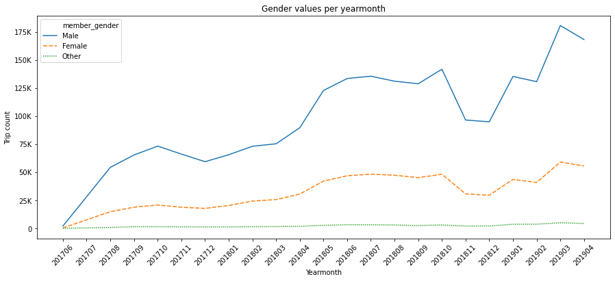

```python
f = plt.figure(figsize=(15, 6))
ax = sns.lineplot(x="yearmonth", y="trip_count",
                  hue="member_gender",
                  style="member_gender",
                  data=df_gender_unique)
plt.title("Gender values per yearmonth")
plt.xlabel('Yearmonth')
plt.ylabel('Trip count')
ax.yaxis.set_major_formatter(FuncFormatter(reformat_large_tick_values))
plt.xticks(rotation=45);
```

## 4.b Age and age group

- Age trip counts is skewed to favor 30 to 35 year olds
- Age is also only available from 201706 through to 201904, and not in all records

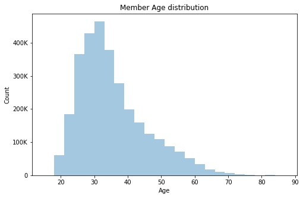

```python
f = plt.figure(figsize=(8, 5))
bin_edges = np.arange(15, df_minutes.member_age.max()+1, 3)
sns.distplot(df_minutes.member_age, bins=bin_edges, kde=False)
plt.title("Member Age distribution")
plt.xlabel('Age')
plt.ylabel('Count')
ax = plt.gca()
ax.yaxis.set_major_formatter(FuncFormatter(reformat_large_tick_values))

plt.show();
```

### Distributions of Age vs User Type

- 25 to 35 year olds dominate, but the Subscribers have a wider range and tend to be older than Customers
- Bike Share subscribers are much more likely to be in the 20-25 years age group, with another smaller peak around 45 years of age

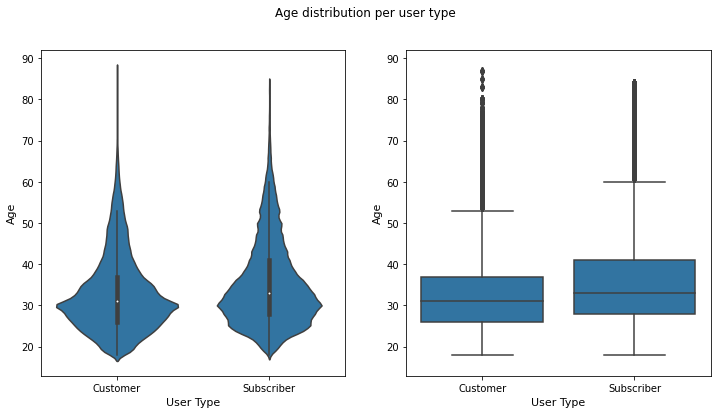

```python
base_color = sns.color_palette()[0]
plt.figure(figsize = [12, 6])

plt.subplot(1, 2, 1)
ax1 = sns.violinplot(data = df_age_mf_dist, x = 'user_type', y = 'member_age', color = base_color)
ax1.set_xlabel('User Type', fontsize=11)
ax1.set_ylabel('Age', fontsize=11)

plt.subplot(1, 2, 2)
ax2 = sns.boxplot(data = df_age_mf_dist, x = 'user_type', y = 'member_age', color = base_color)
ax2.set_xlabel('User Type', fontsize=11)
ax2.set_ylabel('Age', fontsize=11)

plt.ylim(ax1.get_ylim())

plt.suptitle("Age distribution per user type")

plt.show();
```

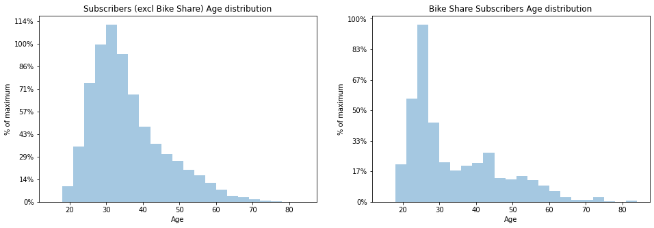

```python
f = plt.figure(figsize=(16, 5))
plt.subplot(1, 2, 1)
bin_edges = np.arange(15, df_minutes.loc[
    (df_minutes.user_type=='Subscriber') &
    (df_minutes.bike_share_for_all_trip!='Yes')].member_age.max()+1, 3)
sns.distplot(df_minutes.loc[
    (df_minutes.user_type=='Subscriber') &
    (df_minutes.bike_share_for_all_trip!='Yes')].member_age, bins=bin_edges, kde=False)
plt.title("Subscribers (excl Bike Share) Age distribution")
plt.xlabel('Age')
plt.ylabel('% of maximum')
perc_fmt = 350000
plt.gca().yaxis.set_major_formatter(PercentFormatter(perc_fmt
                                                    , decimals=0
                                                    ))
plt.subplot(1, 2, 2)
bin_edges = np.arange(15, df_minutes.loc[df_minutes.bike_share_for_all_trip=='Yes'].member_age.max()+1, 3)
sns.distplot(df_minutes.loc[df_minutes.bike_share_for_all_trip=='Yes'].member_age, bins=bin_edges, kde=False)
plt.title("Bike Share Subscribers Age distribution")
plt.xlabel('Age')
plt.ylabel('% of maximum')
perc_fmt = 60000
plt.gca().yaxis.set_major_formatter(PercentFormatter(perc_fmt
                                                    , decimals=0
                                                    ))

plt.show();
```

## 4.c Distributions of Age vs Gender

- All peak around 30 years but the spreads over other ages differ

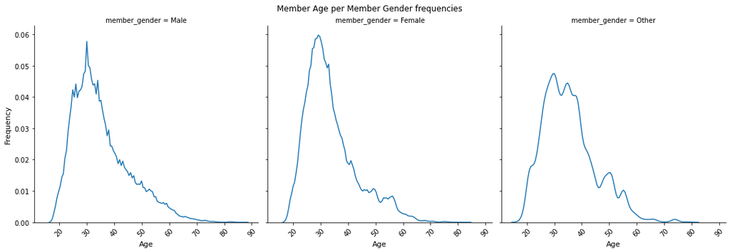

```python
g = sns.FacetGrid(df_age_gender_dist, col="member_gender", height=5)
g.map(sns.kdeplot, "member_age")
plt.suptitle("Member Age per Member Gender frequencies", y=1.02, fontsize=12)
for (i, ax) in enumerate(g.axes.flatten()):
    ax.set_xticklabels(ax.get_xticklabels(), rotation = 45)
    ax.set_xlabel('Age', fontsize=11)
    if i == 0:
        ax.set_ylabel('Frequency', fontsize=11)

plt.show();
```

### Distributions of Age vs Male and Female gender

- The 'Other' gender is not included as the numbers are almost invisible and including them makes it more difficult to visualize the main genders

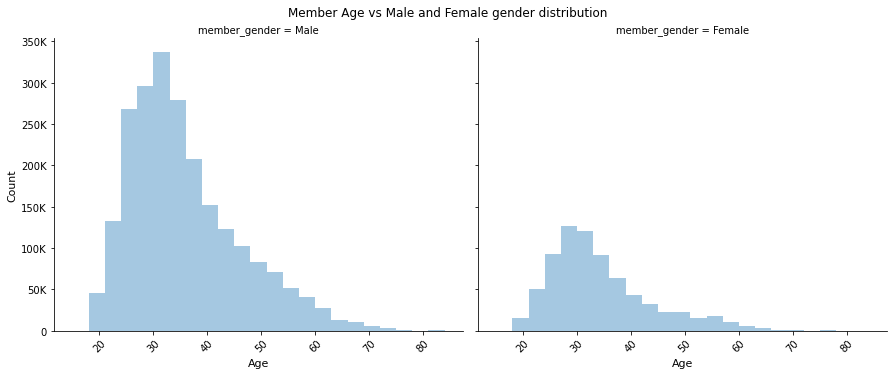

```python
g = sns.FacetGrid(df_age_mf_dist,
                  col="member_gender", height=5, aspect=1.25)
g.map(sns.distplot, "member_age", kde=False, bins=bin_edges)
plt.suptitle("Member Age vs Male and Female gender distribution", y=1.02, fontsize=12)
for (i, ax) in enumerate(g.axes.flatten()):
    ax.set_xticklabels(ax.get_xticklabels(), rotation = 45)
    ax.set_xlabel('Age', fontsize=11)
    if i == 0:
        ax.set_ylabel('Count', fontsize=11)
        ax.yaxis.set_major_formatter(FuncFormatter(reformat_large_tick_values))
plt.show();
```

### Distributions of Age Groups vs Male and Female gender

- As with the age distribution, age groups show users are mostly between 25 and 35 years old, with women tending to be younger

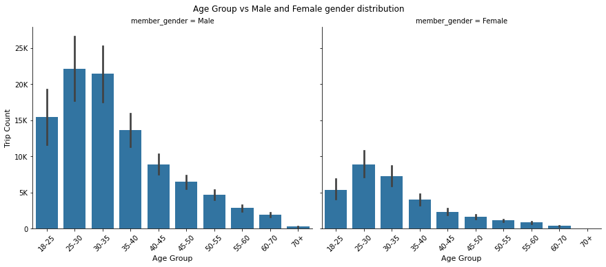

```python
base_color = sns.color_palette()[0]
g = sns.catplot(x="age_group", y="trip_count",
                col="member_gender",
                color = base_color,
                data=df_age_gender,
                kind="bar",
                height=5, aspect=1.25);
g.set_xticklabels(rotation=45)

plt.suptitle("Age Group vs Male and Female gender distribution", y=1.02, fontsize=12)
for (i, ax) in enumerate(g.axes.flatten()):
    ax.set_xticklabels(ax.get_xticklabels(), rotation = 45)
    ax.set_xlabel('Age Group', fontsize=11)
    if i == 0:
        ax.set_ylabel('Trip Count', fontsize=11)
        ax.yaxis.set_major_formatter(FuncFormatter(reformat_large_tick_values))

plt.show();
```

## 4.d Trips counts by Age Groups over time

- over time, the 25-30 year olds dominate 30-35 and 18-25 year olds, but with the latter growing in trip counts
- there is not so much trend of greater growth in any other age groups, apart from the effect of an increase of total counts

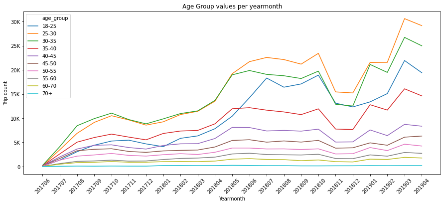

```python
f = plt.figure(figsize=(15, 6))
ax = sns.lineplot(x="yearmonth", y="trip_count",
                  hue="age_group",
                  data=df_age_gender,
                 ci=None)
plt.title("Age Group values per yearmonth")
plt.xlabel('Yearmonth')
plt.ylabel('Trip count')
ax.yaxis.set_major_formatter(FuncFormatter(reformat_large_tick_values))
plt.xticks(rotation=45);
```

### Trips counts by Age Groups and Gender over time

- The same trends exist between genders, only the Male group has greater numbers which amplifies any trends

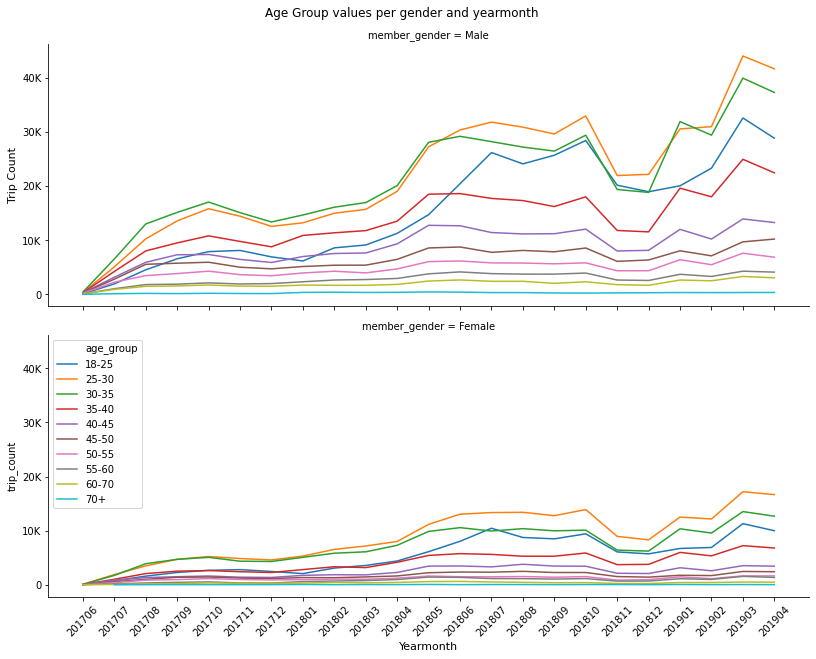

```python
g = sns.FacetGrid(df_age_gender, row="member_gender", height=4.3, aspect=2.7)
cht = g.map(sns.lineplot, "yearmonth", "trip_count", "age_group", ci=None)

plt.suptitle("Age Group values per gender and yearmonth", y=1.02)
for (i, ax) in enumerate(cht.axes.flatten()):
    ax.set_xticklabels(ax.get_xticklabels(), rotation = 45)
    ax.set_xlabel('Yearmonth', fontsize=11)
    if i == 0:
        ax.set_ylabel('Trip Count', fontsize=11)
        ax.yaxis.set_major_formatter(FuncFormatter(reformat_large_tick_values))

plt.legend()
plt.show();
```

## 4.e Distributions of Gender vs User Type

- Based on trip count, a greater proportion of both Male and Female are Subscribers vs Customers
- The previously observed greater number of Male vs Female is again also apparent
- However, there is a closer ratio of Male to Female with Customers, the largest ratio difference is with Subscribers

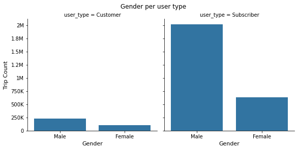

```python
g = sns.FacetGrid(df_age_mf_dist, col="user_type", height=4) #, aspect=1.25)
cht = g.map(sns.countplot, "member_gender")
plt.suptitle("Gender per user type", y=1.02)
for (i, ax) in enumerate(cht.axes.flatten()):
    ax.set_xlabel('Gender', fontsize=11)
    if i == 0:
        ax.set_ylabel('Trip Count', fontsize=11)
        ax.yaxis.set_major_formatter(FuncFormatter(reformat_large_tick_values))
plt.show();
```

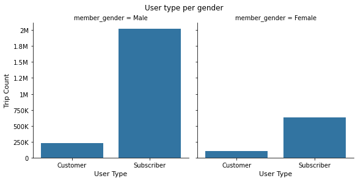

```python
g = sns.FacetGrid(df_age_mf_dist, col="member_gender", height=4) #, aspect=1.25)
cht = g.map(sns.countplot, "user_type")
plt.suptitle("User type per gender", y=1.02)
for (i, ax) in enumerate(cht.axes.flatten()):
    ax.set_xlabel('User Type', fontsize=11)
    if i == 0:
        ax.set_ylabel('Trip Count', fontsize=11)
        ax.yaxis.set_major_formatter(FuncFormatter(reformat_large_tick_values))
plt.show();
```

## 4.f Average Trip durations per week by gender

- The plot shows the difference between Customer and Subscriber times that previous analysis has revealed
- It also splits the data between Male and Female
- With the gender split it can be seen that Females trip durations are on average 5 minutes longer, the ratio is around 5.5 : 4.5, or 10%

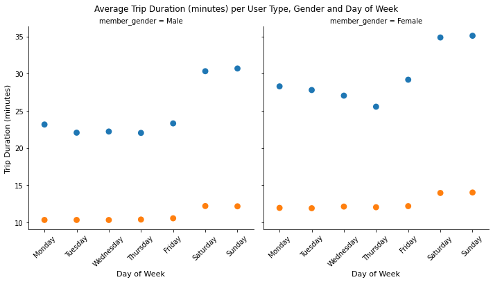

```python
g = sns.FacetGrid(df_mf_trip_summary.loc[df_mf_trip_summary.member_gender.isin(["Male","Female"])],
                  col="member_gender", hue = 'user_type', height=5)
g.map(sns.pointplot, 'start_day_name', 'duration_min',
            linestyles = "")

plt.suptitle("Average Trip Duration (minutes) per User Type, Gender and Day of Week", y=1.02, fontsize=12)
for (i, ax) in enumerate(g.axes.flatten()):
    ax.set_xticklabels(ax.get_xticklabels(), rotation = 45)
    ax.set_xlabel('Day of Week', fontsize=11)
    if i == 0:
        ax.set_ylabel('Trip Duration (minutes)', fontsize=11)

plt.show();
```

# Gender and Age Conclusions

# 5. Geographic Analysis

- Bike trips record starting and finishing geographic points
- Many of these are associated with a station identifier, but there are others which have no station
- There are three main groups, and a few outliers
- Exploratory analysis has just looked at these as groups of data
- Explanatory analysis views geographical information using the on-line version of the Uber developed mapping application kepler.gl
- Do do this, data is exported in CSV form, imported to kepler.gl, interacted with from the web browser, and exported as images for this notebook

## Stations and Dockless Bike locations

- It is assumed that those without station ID / Name are dockless bikes
- Picking only those with more than 2 associated inbound and outbound journeys will eliminate most of the dockless bike journeys
- Some stations have changed their names, but will have a common geographical location

## Map of all geographic locations

- The following map (scroll down) shows the latitude/longitude locations of starting and ending trips,
- but only those having more than 2 associated inbound and outbound journeys,
- this excludes most dockless bike journeys and outliers
- The key locations are in San Francisco, Oakland and Berkeley, and San Jose

[figure not shown]

## San Francisco, Oakland and Berkeley

[figure not shown]

### San Jose and Santa Clara

[figure not shown]

## A look at Precita Park station

- Precita Park, an example of a station, viewed in satellite mode from kepler.gl

[figure not shown]

- And from Google Maps - we can see that the bike station is identified as "Bay Wheels"

[figure not shown]

## Outliers

There were extreme outliers noted in the exploratory analysis, two of these were located in New York City and Montreal!

[figure not shown]

### A peculiar outlier

- Most outliers are dockless bike locations, this one in Lake Merced Park is evidently an underwater laboratory...

[figure not shown]

## Trip visualizations

- kepler.gl allows visualization of trip data using from and to geographic coordinates, as arcs
- This following map of arcs is for the 2017 year

[figure not shown]

## Bike Relocations?

- There is no bike access between San Francisco and Oakland, although there is a bike path between Yerba Buena Island (in the middle of the bay) and Oakland, there is no bike access on the western side through to SF
- Therefore, some trips between SF and Oakland could be bike relocations, as they can only exist if bikes are carried in a vehicle such as truck or ferry
- The large trips between San Jose and San Francisco and Oakland could represent a multi-stop bike bike relocations, it is not a recommended bike journey as it is over 5 hours in horrendous traffic.
- For instance, at 2.6 hours the trip below between SF and San Jose is too short to be a bike ride, and too long for a straightforward drive, but it could represent a multi-stop bike relocation by vehicle.

[figure not shown]

## Trips Across the Bay

- a few of the trips across the bay were exported, based on the longitude of start and end trips positions
- start stations are colored yellow, end stations blue, with the arc transitioning from yellow to blue
- the example below is for 112 minutes, the records range from 32 minutes to 18.6 hrs with an average of 3.85 hours
- it seems likely that many people traveling between the cities are on a recreational bike trip, taking a ferry ride
  - a ferry trip takes from around 30 minutes
- or as noted above, these might represent bike relocations

[figure not shown]

## Long Trips

- Some 52,000 long trips, being over 90 minutes long and coming from all the data, have been exported
- Again there are many that look like transfers between the cities, and some that have made connections even further away
- Scroll down to view the exported long trips

[figure not shown]

## A closer view of the longer trips

- start stations are colored yellow, end stations blue, with the arc transitioning from yellow to blue
- there are too many data points in this dataset to provide anything other than an indication of the variations
- ignoring the likely transfer, many of the longer duration rides are trips between outlying suburbs and the city centers
- however, especially in Oakland and Berkeley there are also many across the suburbs, and between the two cities
- also a cluster of activity in the Santa Clara, to the north of San Jose

### San Francisco and Oakland / Berkeley

[figure not shown]

### San Jose and Santa Clara

[figure not shown]

## A sample of the long trips up to 5 hours

- using a sample of 500 records per year from 2017 to 2019, plus 200 from 2020
- looking at less data makes it easier to understand that most of the longer trips in San Francisco are from suburbs to the city
- and that trips between Berkeley and Oakland, and between Oakland and its south-eastern suburbs dominate on the other side of the harbor

[figure not shown]

## Short Trips samples

- Most trips are less than 30 minutes
- to make it easier to visualize, samples of 1000 per year are used
- the patterns are the same as with the long trips, only the starting point is closer to the target destination
- its easier to see that although the general direction is towards the major hub, many trips are between stations that cross or surround the central point
- interestingly, trips from Berkeley to Oakland still feature, but those from the south-eastern suburbs of Oakland are no longer present

### San Francisco

[figure not shown]

### Oakland and Berkeley

[figure not shown]

### San Jose

[figure not shown]

### Detail of sample of short trips around Lakeside Park and Oakland

- this illustrates how trips connect points around areas of interest. It seems clear that many of these trips would have been around portions of the lake.
- There are busy stations in both Downtown, Uptown and the Financial District of Oakland

[figure not shown]

## Comparisons over time in 2018, San Francisco and Oakland

- Trips on **Wednesday 21st March 2018** vs **Saturday 24th March 2018**
- There were 4,037 trips on the Wednesday and 2,281 trips on the Saturday
- The differences between peak week and weekend times can be seen
- And that there is more activity during the week
- San Francisco has more traffic than Oakland

### Wednesday 21st March 2018

[figure not shown]

### Saturday 24th March 2018

[figure not shown]

## Comparisons over time in 2019, San Francisco and Oakland

- Trips on **Wednesday 20th March 2019** vs **Saturday 23rd March 2019**
- Flows are following similar patterns as 2018, but the length of trips has increased, and new SF stations exist
- There is more use during the day on the Wednesday, with a greater number exiting the city around 5 p.m.
- There were 9,266 trips on the Wednesday, over twice many as the 2018 example; and 6,599 trips on the Saturday - almost 3x as the 2018 Saturday

### Wednesday 20th March 2019

[figure not shown]

### Saturday 23rd March 2019

[figure not shown]

## Comparisons over time in 2020, San Francisco and Oakland

- Trips on **Wednesday 18th March 2020** vs **Saturday 20th March 2020**
- Numbers have dropped considerably, only 2,029 on the Wednesday, less than a quarter of the 2019 figure; and 3,214 on Saturday - half of 2019's trips
- The expected commuting pattern is missing on Wednesday, instead it looks more like a Saturday though with a peak still around 5 p.m.
- The Monday 16th "shelter in place" instruction has obviously affected commuting patterns, but these riders are certainly violating the instruction, many are covering large distances!

### Wednesday 18th March 2020

[figure not shown]

### Saturday 20th March 2020

[figure not shown]

## Three Wednesdays

- Three Wednesdays in mid-March 2018, 2019 and 2020 show remarkable changes, especially when viewed as timelines in the previous slides
- Trip patterns look to have been mostly commuting in 2018 and 2019, and have doubled.
- But in 2020 the trip counts have fallen drastically and it seems more likely that bike riders are enjoying exploratory trips, rather than commuting, maybe reflecting a reaction to price rises, definitely from March 16th in response to coronavirus
- The figures:

  ```
    2018-03-21: 4,036 riders: 3,622 Subscribers,   414 Customers
    2019-03-20: 9,265 riders: 8,152 Subscribers, 1,113 Customers
    2020-03-18: 2,029 riders: 1,187 Subscribers,   842 Customers
  ```

### Wednesday 21st March 2018

[figure not shown]

### Wednesday 20th March 2019

[figure not shown]

### Wednesday 18th March 2020

[figure not shown]

# 6. Conclusion

- The dataset is quite revealing of the fortunes of Ford GoBikes / Lyft Bay Wheels
- Bike usage seems to be linked somewhat to the availability of e-bikes
- There is a definite change for the worse towards the end of the period of the data - March 2020, some of which is likely in response to price hikes
- However, the extraordinary event of the coronavirus must be factored in - on March 16th residents in all of these areas were told to "shelter in place", their normal daily commute was canceled!